# joining

Ben Best

January 29, 2016

## Precursors

### RStudio Heroes

Last weekend at 1st annual [shinydevcon](https://www.rstudio.com/shinydevcon/). Left to right, @github (affiliation):

- Winston Chang @wch (RStudio)
- Hadley Wickham @hadley (RStudio)
- Julie Lowndes @jules32 (OHI)
- Jamie Afflerbach @jafflerbach (OHI)
- Joe Cheng @jcheng5 (RStudio)
- Ben Best @bbest (OHI)
- Herman Strop @FrissAnalytics (FrissAnalytics)

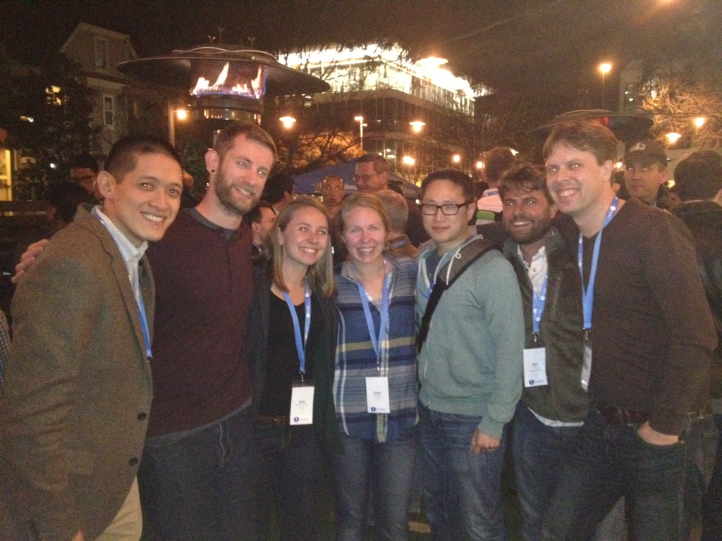

Brought some of these stickers for ya:

[figure not shown]

### RStudio Shortcuts

- rstudio-IDE-cheatsheet.pdf
  - Show Keyboard Shortcuts `?`: Alt+Shift+**K** (Win), Option+Shift+**K** (Mac)
  - (Un)Comment lines `#`: Ctrl+Shift+**C** (Win), Cmd+Shift+**C** (Mac)
  - Insert `%>%`: Ctrl+Shift+**M** (Win), Cmd+Shift+**M** (Mac)
  - Attempt completion: **Tab** or Ctrl+Space (Win), **Tab** or Cmd+Space (Mac),
  - Knit Document: Ctrl+Shift+**K** (Win), Cmd+Shift+**K** (Mac)
  - Copy Lines Up/Down: Shift+Alt+**$\uparrow$**/**$\downarrow$** (Win), Cmd+Option+**$\uparrow$**/**$\downarrow$** (Mac)

### Dealing with Merge Conflicts

[Git and GitHub · R packages – Working with others](http://r-pkgs.had.co.nz/git.html#git-pull)

## joining data

### `bind_cols`

```r
y = data.frame(
  x1 = c('A','B','C'),
  x2 = c( 1 , 2 , 3),
  stringsAsFactors=F)
z = data.frame(
  x1 = c('B','C','D'),
  x2 = c( 2 , 3 , 4),
  stringsAsFactors=F)
y
z
bind_cols(y, z)
```

### `bind_rows`

```r
y
z
bind_rows(y, z)
```

### `union`

```r
y
z
union(y, z)
```

### `intersect`

```r
y
z
intersect(y, z)
```

### `setdiff`

```r
y
z
setdiff(y, z)
```

### `left_join`

```r
songs = data.frame(
  song = c('Across the Universe','Come Together', 'Hello, Goodbye', 'Peggy Sue'),
  name = c('John','John','Paul','Buddy'),
  stringsAsFactors=F)
artists = data.frame(
  name = c('George','John','Paul','Ringo'),
  plays = c('sitar','guitar','bass','drums'),
  stringsAsFactors=F)
left_join(songs, artists, by='name')
```

### `inner_join`

```r
inner_join(songs, artists, by = "name")
```

### `semi_join`

```r
semi_join(songs, artists, by = "name")
```

### `anti_join`

```r
anti_join(songs, artists, by = "name")
```

### summarize per capita CO<sub>2</sub> emissions

You’ll join the gapminder datasets to get world population per country.

**Task**. Report the top 5 emitting countries (not World or EU28) per capita using your long format table. (You may need to convert your year column from factor to numeric, eg `mutate(year = as.numeric(as.character(year)))`. As with most analyses, there are multiple ways to do this. I used the following functions: `filter`, `arrange`, `desc`, `head`).

**Task**. Summarize the total emissions by country (not World or EU28) per capita across years from your long format table and return the top 5 emitting countries. (As with most analyses, there are multiple ways to do this. I used the following functions: `filter`, `arrange`, `desc`, `head`).

```r
library(gapminder) # install.packages('gapminder')
```